# The Team That Kicks More Wins More

Harry Williams

08/01/2021

# 1 Introduction

During the Autumn Nations Cup in November 2020, Eddie Jones was questioned on his team’s decision to kick the ball more in matches. He answered:“The teams that kick the most win games”.[^1] This report will examine match data from the last three years and showcase the evidence and possible explanations behind the correlation between kicking frequency and win rate.

## 1.1 The Data

### 1.1.1 Competitions

Data has been sourced from the Rugby Pass website.[^2] At time of writing this includes a total of 686 professional global Rugby matches over the last 3 years. This includes both international and club rugby games from the following competitions:

| Competition | Type Of Team | Hemisphere |
| --- | --- | --- |
| Autumn Nations Cup | International | Northern |
| Currie Cup | Club | Southern |
| European Champions Cup | Club | Northern |
| Internationals | International | Mixed |
| Mitre 10 Cup | Club | Southern |
| Premiership | Club | Northern |
| Premiership Cup | Club | Northern |
| Pro 14 | Club | Northern |
| Rugby World Cup | International | Mixed |
| Six Nations | International | Northern |
| Super Rugby | Club | Southern |
| Super Rugby Aotearoa | Club | Southern |
| Super Rugby Australia | Club | Southern |
| Super Rugby Unlocked | Club | Southern |
| The Rugby Championship | International | Southern |
| Top 14 | Club | Northern |

### 1.1.2 Variables

The variables collected from each match are as follows:

| Ball Carry | Line Break | Penalty Goal Successful | Scrum Won |
| --- | --- | --- | --- |
| Ball Carry Meters | Lineout Throw Won Clean | Penalty Missed | Tackle Made |
| Beat Defender | Lineout Won Own Throw | Points Scored | Tackle Missed |
| Conversion Missed | Lineout Won Steal | Possession | Total Turnovers Conceded |
| Conversion Successful | Mauls Won | Red Card | Total Turnovers Gained |
| Drop Goal Missed | Offload | Rucks Lost | Try Assist |
| Drop Kick Successful | Passes | Rucks Won | Try Scored |
| Kicks From Hand | Penalties Conceded | Scrum Lost | Yellow Card |

### 1.1.3 Three Key Variables

The first key variable explored in this investigation is `Kicks From Hand`. This is the total number of kicks in play but does not include penalty kicks. `Win Rate` is the second key variable explored, and can be defined as the percentage number of wins for a team. Finally `Kick Rate`, which is the percentage number of times a team has kicked more than their opposition. `Win Rate` and `Kick Rate` have been calculated in the following ways:

$$Win\:Rate = \frac{Number\:of\:Matches\:Won}{Total\:Matches\:Played}$$

$$Kick\:Rate = \frac{Number\:of\:Times\:Kicked\: More\: Than\: Opposition}{Total\:Matches\:Played}$$

### 1.1.4 Data Limitions

#### 1.1.4.1 Rugby Pass Data

| Year | Count |
| --- | --- |
| 2018 | 114 |
| 2019 | 152 |
| 2020 | 303 |
| 2021 | 117 |

#### 1.1.4.2 Variable Limitions

`Kicks From Hand` only includes the total number of kicks made in each match. The dataset does not give a more precise count of different types of kicks in a match. Tactically, a kick from a team’s own 22 is very different from a kick from the halfway line or inside the opposition’s half. A breakdown of the number of kicks by territory would better reflect this. This can also be applied to penalties as it is difficult to determine how each penalty was conceded e.g. from the breakdown or scrum. This data would offer a much more detailed analysis than what the current dataset allows.

# 2 Analysis

## 2.1 Teams that kicks more than the opposition

### 2.1.1 Percentage Number of Match Wins

Using the data, the percentage number of wins for teams that kick more than their opponents are as follows:

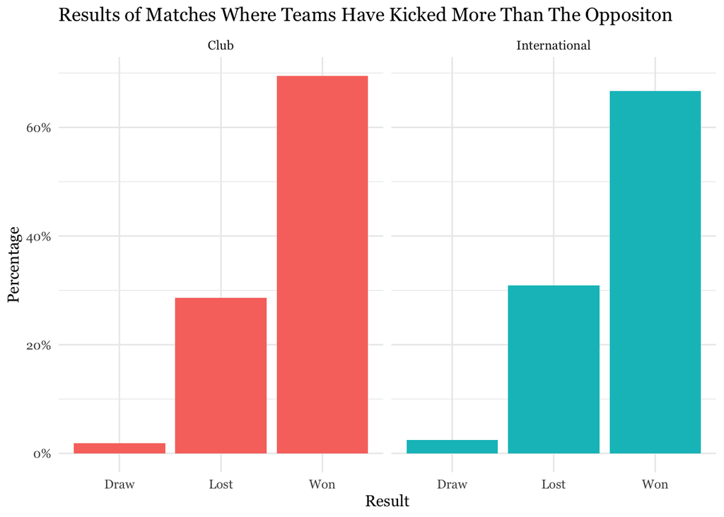

This graph shows the results when a team has kicked more than the opposition, split over both club and international games. The data shows that teams that kick more frequently than their opponents won around 69% of their matches.

### 2.1.2 Hypothesis Test

Since this dataset is a sample, a hypothesis test needs to be carried out to confirm if 69% is representative across all professional matches. The method for the test can be found in the dropdown.

**Hypothesis Test**

If kicking had no impact on the win rate of matches, the expected proportion of matches won would be around 50%. A hypothesis test can be used to see if the dataset reflects the whole population or simply sampling variation.

The Hypothesis test can be defined as follows:

H<sub>0</sub>: π matches won = 0.5

H<sub>A</sub>: π matches won > 0.5

α = 0.05

When looking at teams that kick more than their opposition, if the p-value is greater than 0.05 then we accept H<sub>0</sub>. We can then conclude that the proportion of the number of matches won should be around 50%. If the p-value is less than 0.05 then H<sub>0</sub> is rejected in favour of H<sub>A</sub>. If this is the case, we can then conclude that the proportion of the number of matches won is greater than 50%.

```r
tset_matches_sample <- test_matches

null_distribution <- tset_matches_sample %>%
  specify(response = won, success = "TRUE") %>%
  hypothesize(null = "point", p = 0.5) %>%
  generate(reps = 10000, type = "simulate") %>%
  calculate(stat = "prop")

observed_stat <- tset_matches_sample %>%
  specify(response = won, success = "TRUE") %>%
  calculate(stat = "prop")
```

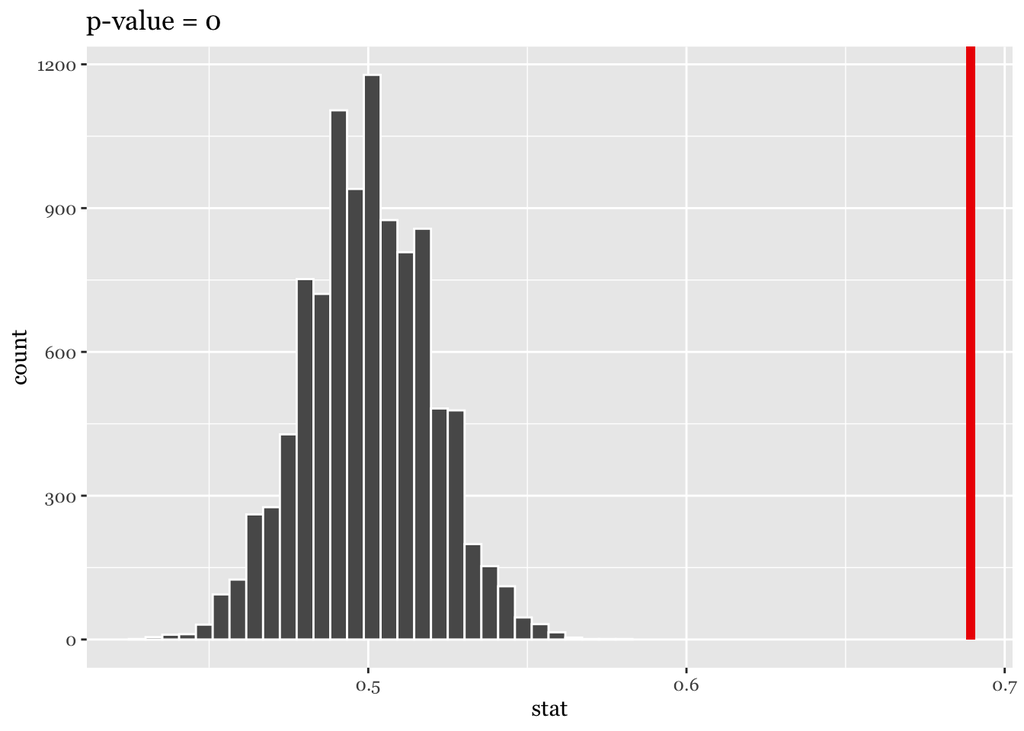

```r
p_value <- null_distribution %>%
  get_p_value(obs_stat = observed_stat, direction = "both")


null_distribution %>%
  visualise(bins = 30) +
  shade_p_value(obs_stat = observed_stat, direction = "right") +
  labs(title = paste("p-value =", p_value)) +
  theme(text = element_text(family = "Georgia"))
```

The p-value is less than α, so H<sub>0</sub> is rejected in favour of H<sub>A</sub>. There is enough evidence from the data to suggest that the proportion of wins is statistically significantly greater than the null value. This means that statistically, teams that kick more than their opponents win a larger proportion of their games.

### 2.1.3 Results of the test

The hypothesis test has shown that there is enough evidence from this dataset to reliably conclude that teams that kick more than their opponent will win more of their games.

A further computation can be carried out to give a percentage range within a 95% confidence interval of the population.

### 2.1.4 Estimated Percentage Wins

| Lower Confidence Interval | Upper Confidence Interval |
| --- | --- |
| 65.22% | 72.33% |

From this dataset, it is estimated that teams that kick more than their opponents win between 65.22% - 72.33% of their total matches within a 95% confidence interval.

## 2.2 Win Rate vs Kick Rate

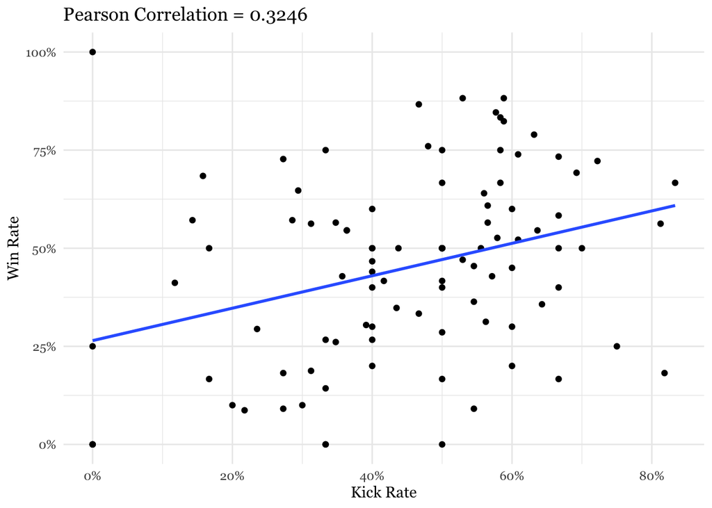

Plotting `Win Rate` and `Kick Rate` there is a moderate correlation of 0.3246. While there is quite a lot of spread within the data, there is still a general trend: teams that have a higher kick rate also have a higher win rate. As there is a moderate correlation, other variables can also be used to explain `Win Rate`.

## 2.3 Win Rate vs Average Number of Kicks per Game

### 2.3.1 Top 10 teams by Average Number of Kicks per Game

| Rank | Team | Avg. No. Kicks Per Game | Draw | Lost | Won | Win Rate |
| --- | --- | --- | --- | --- | --- | --- |
| 1 | Western Force | 34.18 | 0 | 10 | 1 | 9.09% |
| 2 | England | 29.80 | 1 | 5 | 19 | 76% |
| 3 | France | 28.89 | 0 | 9 | 10 | 52.63% |
| 4 | Harlequins | 28.31 | 1 | 6 | 9 | 56.25% |
| 5 | South Africa | 26.31 | 1 | 3 | 9 | 69.23% |
| 6 | Wales | 26.12 | 0 | 4 | 22 | 84.62% |
| 7 | Scotland | 25.60 | 1 | 10 | 9 | 45% |
| 8 | Benetton Treviso | 25.00 | 0 | 12 | 0 | 0% |
| 9 | Ospreys | 24.73 | 0 | 8 | 7 | 46.67% |
| 10 | Newcastle Falcons | 24.70 | 0 | 5 | 5 | 50% |

The split can be shown as follows:

| Type Of Team | Avg. No. Kicks Per Games |
| --- | --- |
| Club | 20.25 |
| International | 23.72 |

### 2.3.2 Win Rate vs Average Number of Kicks per Game Plot

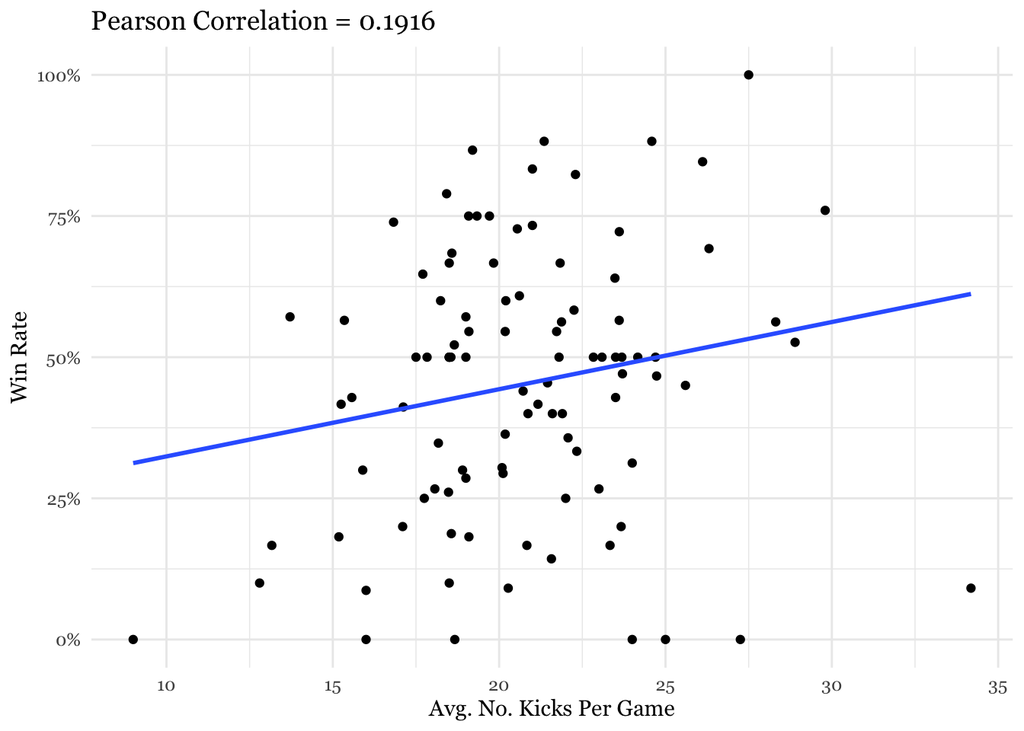

## 2.4 Further Exploration

As the data is more complete when looking at international matches, this exploration will now only focus on the international game.

### 2.4.1 Correlation with `Kicks From Hand`

Below is a graph showing which other variables correlate with `Kicks From Hand`:

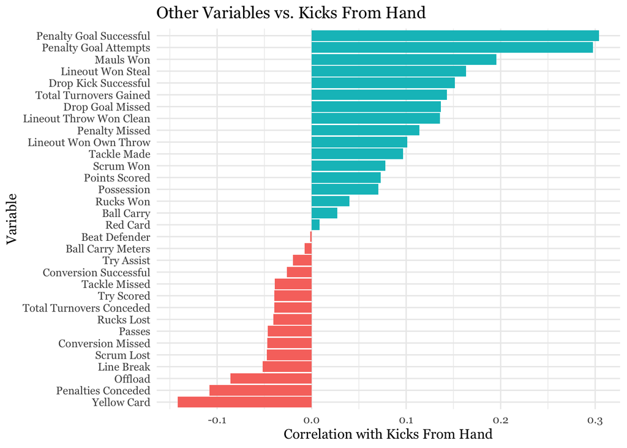

Any correlation score over 0.2 is weak. There appears to be a weak correlation between the number of `Kicks from Hand` and the number of `Penalty Goal Successful` and `Penalty Goal Attempts`. This could explain some of the reasons why teams that kick more than their opponent have a higher chance of winning.

Unfortunately the data variables are not suited to make an accurate model to explain this link. However, the data can offer some insight by highlighting key variables within an explanatory model.

### 2.4.2 Explanatory Model

**Model Construction**

Penalty Goal Successful and team both look like good options

```r
mod1a <- lm(kicks_from_hand ~ team, data = model_data)
```

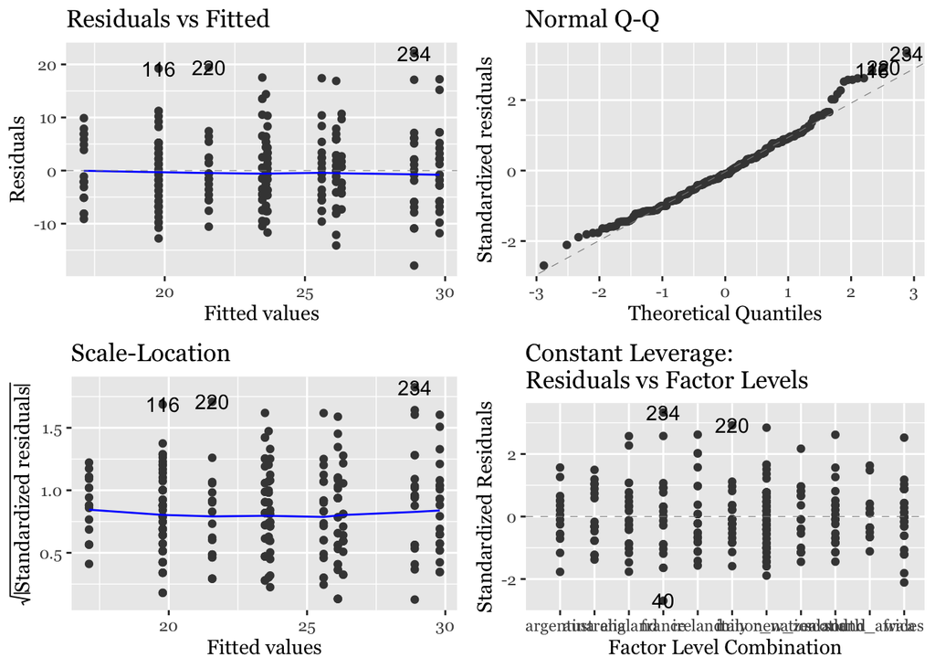

```r
autoplot(mod1a) +
  theme(text = element_text(family = "Georgia"))
```

```r
summary(mod1a)
```

```
##
## Call:
## lm(formula = kicks_from_hand ~ team, data = model_data)
##
## Residuals:
##      Min       1Q   Median       3Q      Max
## -17.8947  -4.5929  -0.6389   4.2182  22.1053
##
## Coefficients:
##                  Estimate Std. Error t value Pr(>|t|)
## (Intercept)        17.118      1.655  10.346  < 2e-16 ***
## teamnew_zealand     6.493      2.307   2.815 0.005285 **
## teamengland        12.682      2.144   5.914 1.13e-08 ***
## teamsouth_africa    9.190      2.513   3.656 0.000313 ***
## teamireland         6.362      2.144   2.967 0.003309 **
## teamitaly           4.454      2.226   2.001 0.046489 *
## teamminor_nation    2.664      1.893   1.407 0.160595
## teamscotland        8.482      2.250   3.769 0.000206 ***
## teamwales           8.998      2.128   4.229 3.33e-05 ***
## teamfrance         11.777      2.277   5.171 4.86e-07 ***
## teamargentina       6.549      2.417   2.710 0.007206 **
## ---
## Signif. codes:  0 '***' 0.001 '**' 0.01 '*' 0.05 '.' 0.1 ' ' 1
##
## Residual standard error: 6.822 on 243 degrees of freedom
## Multiple R-squared:  0.2329, Adjusted R-squared:  0.2013
## F-statistic: 7.376 on 10 and 243 DF,  p-value: 3.325e-10
```

As with the top 10 teams with the highest average kicks per game, England, France, South Africa, Wales contribute towards kicking more in matches

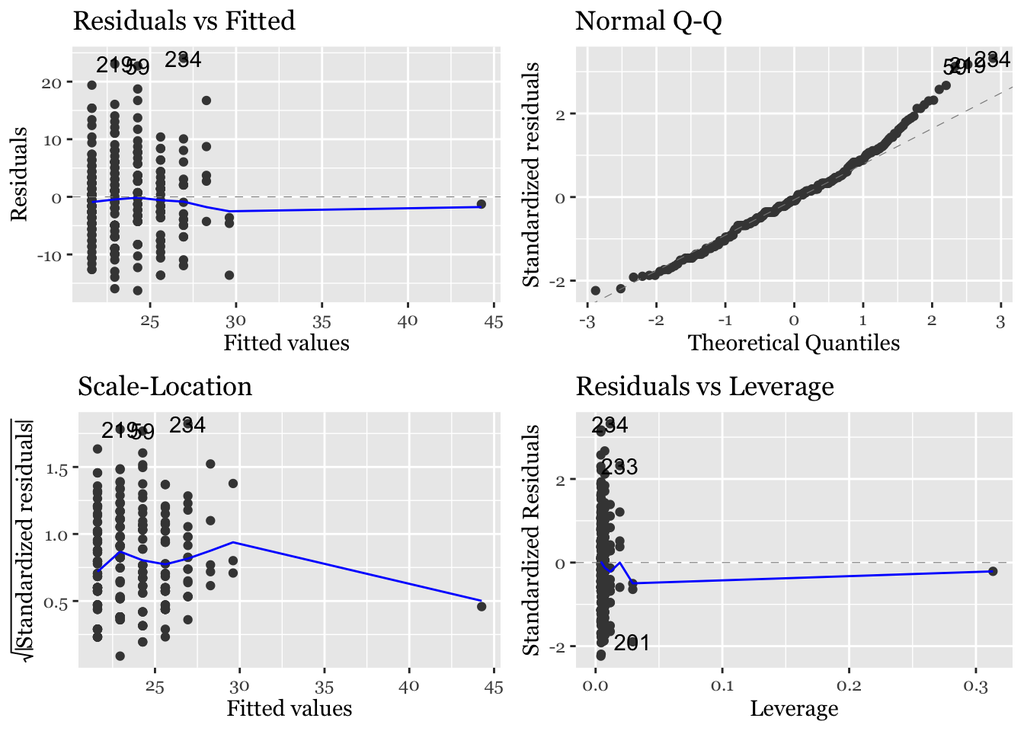

```r
mod1b <- lm(kicks_from_hand ~ penalty_goal_successful, data = model_data)

autoplot(mod1b) +
  theme(text = element_text(family = "Georgia"))
```

```r
summary(mod1b)
```

```
##
## Call:
## lm(formula = kicks_from_hand ~ penalty_goal_successful, data = model_data)
##
## Residuals:
##      Min       1Q   Median       3Q      Max
## -16.2754  -4.6097  -0.6097   3.7246  24.0590
##
## Coefficients:
##                         Estimate Std. Error t value Pr(>|t|)
## (Intercept)              21.6097     0.6189  34.914  < 2e-16 ***
## penalty_goal_successful   1.3328     0.2630   5.068 7.78e-07 ***
## ---
## Signif. codes:  0 '***' 0.001 '**' 0.01 '*' 0.05 '.' 0.1 ' ' 1
##
## Residual standard error: 7.286 on 252 degrees of freedom
## Multiple R-squared:  0.0925, Adjusted R-squared:  0.0889
## F-statistic: 25.69 on 1 and 252 DF,  p-value: 7.777e-07
```

mod1a has the highest r^2 so that will be used.

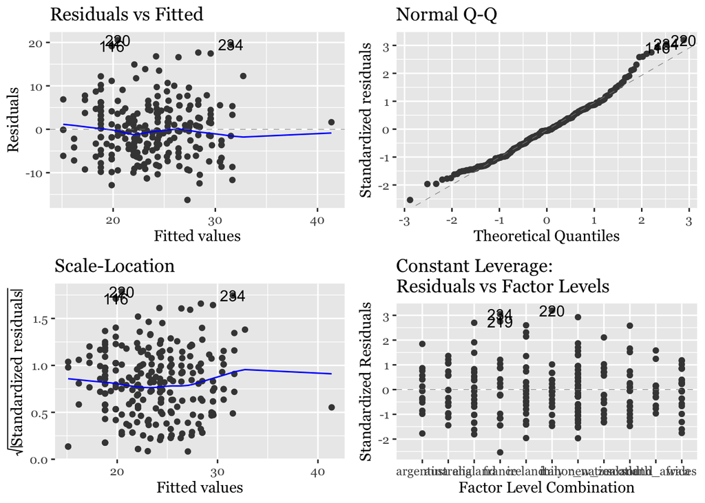

```r
mod2a <- lm(kicks_from_hand ~ team + penalty_goal_successful, data = model_data)

autoplot(mod2a) +
  theme(text = element_text(family = "Georgia"))
```

```r
summary(mod2a)
```

```
##
## Call:
## lm(formula = kicks_from_hand ~ team + penalty_goal_successful,
##     data = model_data)
##
## Residuals:
##      Min       1Q   Median       3Q      Max
## -16.2722  -4.4427  -0.3342   4.1251  20.5422
##
## Coefficients:
##                         Estimate Std. Error t value Pr(>|t|)
## (Intercept)              15.1166     1.6712   9.045  < 2e-16 ***
## teamnew_zealand           7.2543     2.2401   3.238 0.001371 **
## teamengland              12.3022     2.0773   5.922 1.08e-08 ***
## teamsouth_africa          8.7379     2.4348   3.589 0.000402 ***
## teamireland               6.9602     2.0803   3.346 0.000951 ***
## teamitaly                 5.3411     2.1643   2.468 0.014286 *
## teamminor_nation          3.6795     1.8480   1.991 0.047603 *
## teamscotland              9.1546     2.1838   4.192 3.88e-05 ***
## teamwales                 8.1776     2.0685   3.953 0.000101 ***
## teamfrance               12.1556     2.2059   5.511 9.14e-08 ***
## teamargentina             6.0696     2.3415   2.592 0.010116 *
## penalty_goal_successful   1.0630     0.2544   4.179 4.10e-05 ***
## ---
## Signif. codes:  0 '***' 0.001 '**' 0.01 '*' 0.05 '.' 0.1 ' ' 1
##
## Residual standard error: 6.602 on 242 degrees of freedom
## Multiple R-squared:  0.2845, Adjusted R-squared:  0.252
## F-statistic: 8.747 on 11 and 242 DF,  p-value: 4.908e-13
```

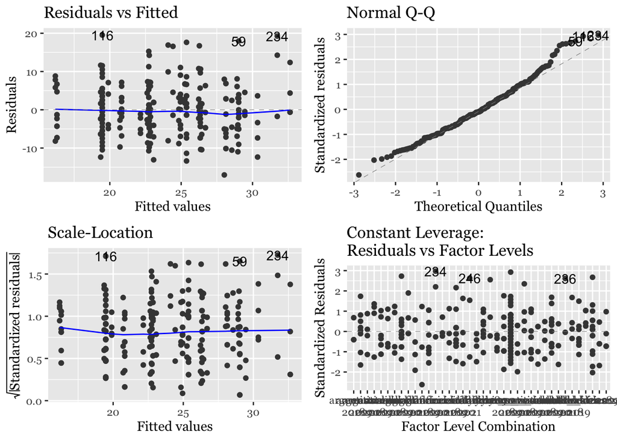

```r
mod2b <- lm(kicks_from_hand ~ team + year, data = model_data)

autoplot(mod2b) +
  theme(text = element_text(family = "Georgia"))
```

```r
summary(mod2b)
```

```
##
## Call:
## lm(formula = kicks_from_hand ~ team + year, data = model_data)
##
## Residuals:
##      Min       1Q   Median       3Q      Max
## -17.0226  -4.6991  -0.6398   3.6405  19.5269
##
## Coefficients:
##                  Estimate Std. Error t value Pr(>|t|)
## (Intercept)       16.1847     1.8391   8.801 2.73e-16 ***
## teamnew_zealand    6.5453     2.2790   2.872 0.004444 **
## teamengland       12.7330     2.1357   5.962 8.85e-09 ***
## teamsouth_africa  10.0449     2.4987   4.020 7.79e-05 ***
## teamireland        6.4660     2.1293   3.037 0.002656 **
## teamitaly          4.5292     2.2213   2.039 0.042546 *
## teamminor_nation   3.1756     1.8817   1.688 0.092784 .
## teamscotland       8.6529     2.2303   3.880 0.000135 ***
## teamwales          9.0780     2.1187   4.285 2.65e-05 ***
## teamfrance        11.8379     2.2658   5.225 3.79e-07 ***
## teamargentina      6.4321     2.3872   2.694 0.007548 **
## year2019           0.1128     1.1263   0.100 0.920315
## year2020           3.7112     1.4759   2.514 0.012577 *
## year2021           1.4364     1.8574   0.773 0.440092
## ---
## Signif. codes:  0 '***' 0.001 '**' 0.01 '*' 0.05 '.' 0.1 ' ' 1
##
## Residual standard error: 6.737 on 240 degrees of freedom
## Multiple R-squared:  0.261,  Adjusted R-squared:  0.2209
## F-statistic: 6.519 on 13 and 240 DF,  p-value: 1.346e-10
```

mod2a has the highest r^2 so is the best option

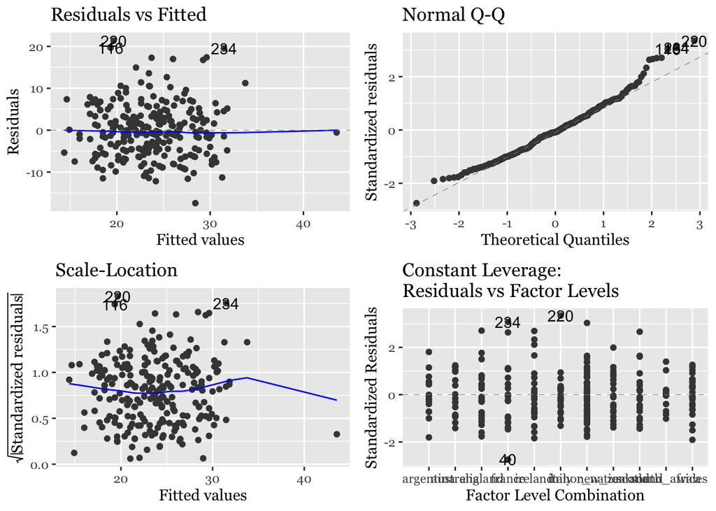

```r
mod3a <- lm(kicks_from_hand ~ team + penalty_goal_successful + lineout_won_own_throw, data = model_data)

autoplot(mod3a) +
  theme(text = element_text(family = "Georgia"))
```

```r
summary(mod3a)
```

```
##
## Call:
## lm(formula = kicks_from_hand ~ team + penalty_goal_successful +
##     lineout_won_own_throw, data = model_data)
##
## Residuals:
##      Min       1Q   Median       3Q      Max
## -17.4136  -4.6043  -0.5185   3.4636  21.3449
##
## Coefficients:
##                         Estimate Std. Error t value Pr(>|t|)
## (Intercept)              11.8937     2.1944   5.420 1.44e-07 ***
## teamnew_zealand           7.6887     2.2302   3.448 0.000667 ***
## teamengland              12.7761     2.0711   6.169 2.89e-09 ***
## teamsouth_africa          8.7634     2.4148   3.629 0.000347 ***
## teamireland               7.1469     2.0649   3.461 0.000636 ***
## teamitaly                 5.5724     2.1490   2.593 0.010096 *
## teamminor_nation          4.4082     1.8615   2.368 0.018669 *
## teamscotland              9.4485     2.1698   4.355 1.97e-05 ***
## teamwales                 8.4508     2.0551   4.112 5.38e-05 ***
## teamfrance               12.6891     2.2007   5.766 2.47e-08 ***
## teamargentina             6.0323     2.3223   2.598 0.009967 **
## penalty_goal_successful   1.1078     0.2531   4.377 1.80e-05 ***
## lineout_won_own_throw     0.2736     0.1221   2.241 0.025924 *
## ---
## Signif. codes:  0 '***' 0.001 '**' 0.01 '*' 0.05 '.' 0.1 ' ' 1
##
## Residual standard error: 6.548 on 241 degrees of freedom
## Multiple R-squared:  0.2991, Adjusted R-squared:  0.2642
## F-statistic:  8.57 on 12 and 241 DF,  p-value: 1.596e-13
```

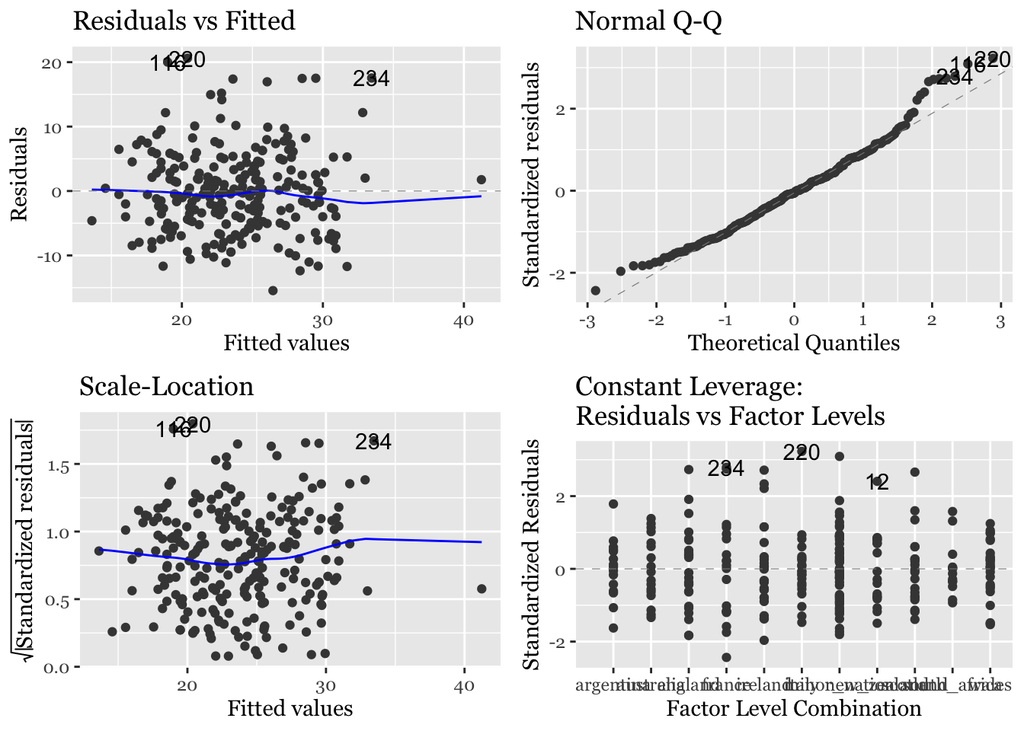

```r
mod3b <- lm(kicks_from_hand ~ team + penalty_goal_successful + total_turnovers_gained, data = model_data)

autoplot(mod3b) +
  theme(text = element_text(family = "Georgia"))
```

```r
summary(mod3b)
```

```
##
## Call:
## lm(formula = kicks_from_hand ~ team + penalty_goal_successful +
##     total_turnovers_gained, data = model_data)
##
## Residuals:
##      Min       1Q   Median       3Q      Max
## -15.4592  -4.5256  -0.3573   3.8169  20.6068
##
## Coefficients:
##                         Estimate Std. Error t value Pr(>|t|)
## (Intercept)              12.6558     1.9700   6.424 7.02e-10 ***
## teamnew_zealand           6.9752     2.2237   3.137 0.001920 **
## teamengland              12.3787     2.0593   6.011 6.77e-09 ***
## teamsouth_africa          7.6925     2.4554   3.133 0.001945 **
## teamireland               7.1440     2.0635   3.462 0.000634 ***
## teamitaly                 6.1371     2.1728   2.825 0.005131 **
## teamminor_nation          3.9435     1.8353   2.149 0.032656 *
## teamscotland              9.5722     2.1720   4.407 1.58e-05 ***
## teamwales                 8.1131     2.0504   3.957 1.00e-04 ***
## teamfrance               12.2030     2.1865   5.581 6.42e-08 ***
## teamargentina             6.0948     2.3208   2.626 0.009189 **
## penalty_goal_successful   1.1101     0.2530   4.388 1.71e-05 ***
## total_turnovers_gained    0.3201     0.1387   2.308 0.021860 *
## ---
## Signif. codes:  0 '***' 0.001 '**' 0.01 '*' 0.05 '.' 0.1 ' ' 1
##
## Residual standard error: 6.544 on 241 degrees of freedom
## Multiple R-squared:    0.3,  Adjusted R-squared:  0.2651
## F-statistic: 8.605 on 12 and 241 DF,  p-value: 1.396e-13
```

```r
mod4a <- lm(kicks_from_hand ~ team + penalty_goal_successful + lineout_won_own_throw + line_break, data = model_data)

summary(mod4a)
```

```
##
## Call:
## lm(formula = kicks_from_hand ~ team + penalty_goal_successful +
##     lineout_won_own_throw + line_break, data = model_data)
##
## Residuals:
##      Min       1Q   Median       3Q      Max
## -17.5435  -4.6305  -0.6053   3.7343  20.5002
##
## Coefficients:
##                         Estimate Std. Error t value Pr(>|t|)
## (Intercept)             13.02141    2.22147   5.862 1.51e-08 ***
## teamnew_zealand          8.45250    2.23013   3.790 0.000190 ***
## teamengland             13.12223    2.05532   6.385 8.81e-10 ***
## teamsouth_africa         9.03155    2.39315   3.774 0.000203 ***
## teamireland              6.87514    2.04726   3.358 0.000912 ***
## teamitaly                5.29009    2.13067   2.483 0.013719 *
## teamminor_nation         4.14651    1.84598   2.246 0.025599 *
## teamscotland             9.72318    2.15104   4.520 9.71e-06 ***
## teamwales                8.36665    2.03481   4.112 5.40e-05 ***
## teamfrance              12.89659    2.18030   5.915 1.14e-08 ***
## teamargentina            5.85113    2.30025   2.544 0.011597 *
## penalty_goal_successful  1.07891    0.25085   4.301 2.48e-05 ***
## lineout_won_own_throw    0.29762    0.12127   2.454 0.014832 *
## line_break              -0.19265    0.07931  -2.429 0.015874 *
## ---
## Signif. codes:  0 '***' 0.001 '**' 0.01 '*' 0.05 '.' 0.1 ' ' 1
##
## Residual standard error: 6.482 on 240 degrees of freedom
## Multiple R-squared:  0.3159, Adjusted R-squared:  0.2789
## F-statistic: 8.526 on 13 and 240 DF,  p-value: 3.508e-14
```

```r
mod4b <- lm(kicks_from_hand ~ team + penalty_goal_successful + lineout_won_own_throw + total_turnovers_gained, data = model_data)

summary(mod4b)
```

```
##
## Call:
## lm(formula = kicks_from_hand ~ team + penalty_goal_successful +
##     lineout_won_own_throw + total_turnovers_gained, data = model_data)
##
## Residuals:
##      Min       1Q   Median       3Q      Max
## -16.6013  -4.5828  -0.2617   3.5085  21.4110
##
## Coefficients:
##                         Estimate Std. Error t value Pr(>|t|)
## (Intercept)               9.4223     2.4190   3.895 0.000127 ***
## teamnew_zealand           7.4100     2.2132   3.348 0.000944 ***
## teamengland              12.8537     2.0526   6.262 1.74e-09 ***
## teamsouth_africa          7.7162     2.4346   3.169 0.001726 **
## teamireland               7.3315     2.0477   3.580 0.000415 ***
## teamitaly                 6.3702     2.1568   2.954 0.003454 **
## teamminor_nation          4.6741     1.8481   2.529 0.012076 *
## teamscotland              9.8674     2.1576   4.573 7.69e-06 ***
## teamwales                 8.3866     2.0366   4.118 5.26e-05 ***
## teamfrance               12.7377     2.1808   5.841 1.68e-08 ***
## teamargentina             6.0575     2.3012   2.632 0.009032 **
## penalty_goal_successful   1.1550     0.2516   4.590 7.14e-06 ***
## lineout_won_own_throw     0.2741     0.1210   2.266 0.024341 *
## total_turnovers_gained    0.3206     0.1375   2.332 0.020548 *
## ---
## Signif. codes:  0 '***' 0.001 '**' 0.01 '*' 0.05 '.' 0.1 ' ' 1
##
## Residual standard error: 6.488 on 240 degrees of freedom
## Multiple R-squared:  0.3146, Adjusted R-squared:  0.2775
## F-statistic: 8.475 on 13 and 240 DF,  p-value: 4.304e-14
```

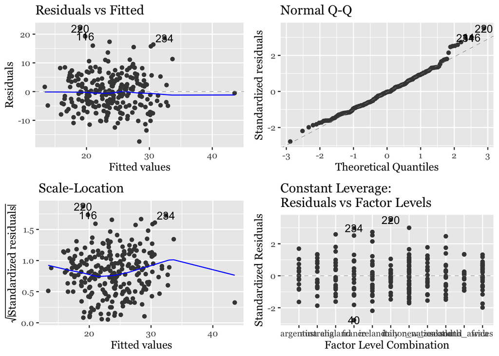

```r
mod4c <- lm(kicks_from_hand ~ team + penalty_goal_successful + lineout_won_own_throw + lineout_won_steal, data = model_data)

autoplot(mod4c) +
  theme(text = element_text(family = "Georgia"))
```